```python
import pandas as pd
import numpy as np
import matplotlib.pyplot as plt
import seaborn as sns
```

# Get the dataset and information

```python
df=pd.read_csv('diabetes.csv')
df.head()
```

|  | Pregnancies | Glucose | BloodPressure | SkinThickness | Insulin | BMI | DiabetesPedigreeFunction | Age | Outcome |
| --- | --- | --- | --- | --- | --- | --- | --- | --- | --- |
| 0 | 6 | 148 | 72 | 35 | 0 | 33.6 | 0.627 | 50 | 1 |
| 1 | 1 | 85 | 66 | 29 | 0 | 26.6 | 0.351 | 31 | 0 |
| 2 | 8 | 183 | 64 | 0 | 0 | 23.3 | 0.672 | 32 | 1 |
| 3 | 1 | 89 | 66 | 23 | 94 | 28.1 | 0.167 | 21 | 0 |
| 4 | 0 | 137 | 40 | 35 | 168 | 43.1 | 2.288 | 33 | 1 |

```python
df.shape
```

```
(768, 9)
```

```python
df.columns
```

```
Index(['Pregnancies', 'Glucose', 'BloodPressure', 'SkinThickness', 'Insulin',
       'BMI', 'DiabetesPedigreeFunction', 'Age', 'Outcome'],
      dtype='object')
```

```python
df.info()
```

```
<class 'pandas.core.frame.DataFrame'>
RangeIndex: 768 entries, 0 to 767
Data columns (total 9 columns):
 #   Column                    Non-Null Count  Dtype
---  ------                    --------------  -----
 0   Pregnancies               768 non-null    int64
 1   Glucose                   768 non-null    int64
 2   BloodPressure             768 non-null    int64
 3   SkinThickness             768 non-null    int64
 4   Insulin                   768 non-null    int64
 5   BMI                       768 non-null    float64
 6   DiabetesPedigreeFunction  768 non-null    float64
 7   Age                       768 non-null    int64
 8   Outcome                   768 non-null    int64
dtypes: float64(2), int64(7)
memory usage: 54.1 KB
```

# Finding the Null Value

```python
df.isna().sum()
```

```
Pregnancies                 0
Glucose                     0
BloodPressure               0
SkinThickness               0
Insulin                     0
BMI                         0
DiabetesPedigreeFunction    0
Age                         0
Outcome                     0
dtype: int64
```

# Statistical Table

```python
df.describe()
```

|  | Pregnancies | Glucose | BloodPressure | SkinThickness | Insulin | BMI | DiabetesPedigreeFunction | Age | Outcome |
| --- | --- | --- | --- | --- | --- | --- | --- | --- | --- |
| count | 768.000000 | 768.000000 | 768.000000 | 768.000000 | 768.000000 | 768.000000 | 768.000000 | 768.000000 | 768.000000 |
| mean | 3.845052 | 120.894531 | 69.105469 | 20.536458 | 79.799479 | 31.992578 | 0.471876 | 33.240885 | 0.348958 |
| std | 3.369578 | 31.972618 | 19.355807 | 15.952218 | 115.244002 | 7.884160 | 0.331329 | 11.760232 | 0.476951 |
| min | 0.000000 | 0.000000 | 0.000000 | 0.000000 | 0.000000 | 0.000000 | 0.078000 | 21.000000 | 0.000000 |
| 25% | 1.000000 | 99.000000 | 62.000000 | 0.000000 | 0.000000 | 27.300000 | 0.243750 | 24.000000 | 0.000000 |
| 50% | 3.000000 | 117.000000 | 72.000000 | 23.000000 | 30.500000 | 32.000000 | 0.372500 | 29.000000 | 0.000000 |
| 75% | 6.000000 | 140.250000 | 80.000000 | 32.000000 | 127.250000 | 36.600000 | 0.626250 | 41.000000 | 1.000000 |
| max | 17.000000 | 199.000000 | 122.000000 | 99.000000 | 846.000000 | 67.100000 | 2.420000 | 81.000000 | 1.000000 |

# Correlation Matrix

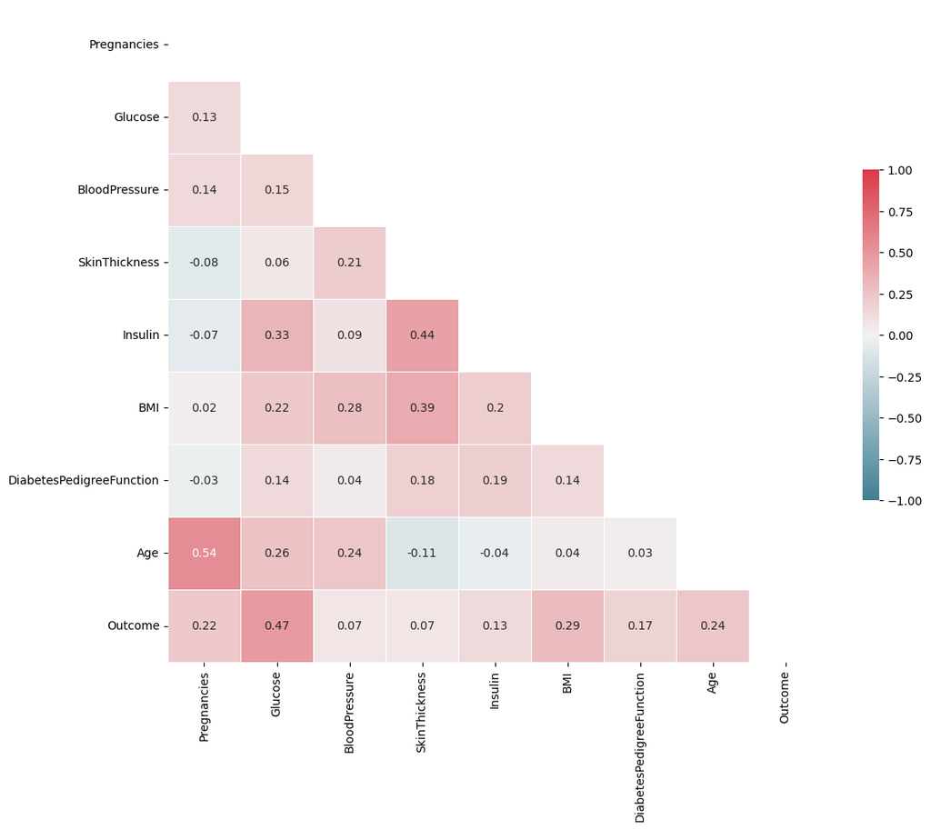

```python
# Generate and visualize the correlation matrix
corr = df.corr().round(2)

# Mask for the upper triangle
mask = np.zeros_like(corr, dtype=np.bool_)  # Correct dtype
mask[np.triu_indices_from(mask)] = True

# Set figure size
f, ax = plt.subplots(figsize=(12, 10))  # Adjusted for better readability

# Define custom colormap
cmap = sns.diverging_palette(220, 10, as_cmap=True)

# Draw the heatmap
sns.heatmap(corr, mask=mask, cmap=cmap, vmin=-1, vmax=1, center=0,
            square=True, linewidths=.5, cbar_kws={"shrink": .5}, annot=True)

plt.tight_layout()
plt.show()
```

# Heatmap

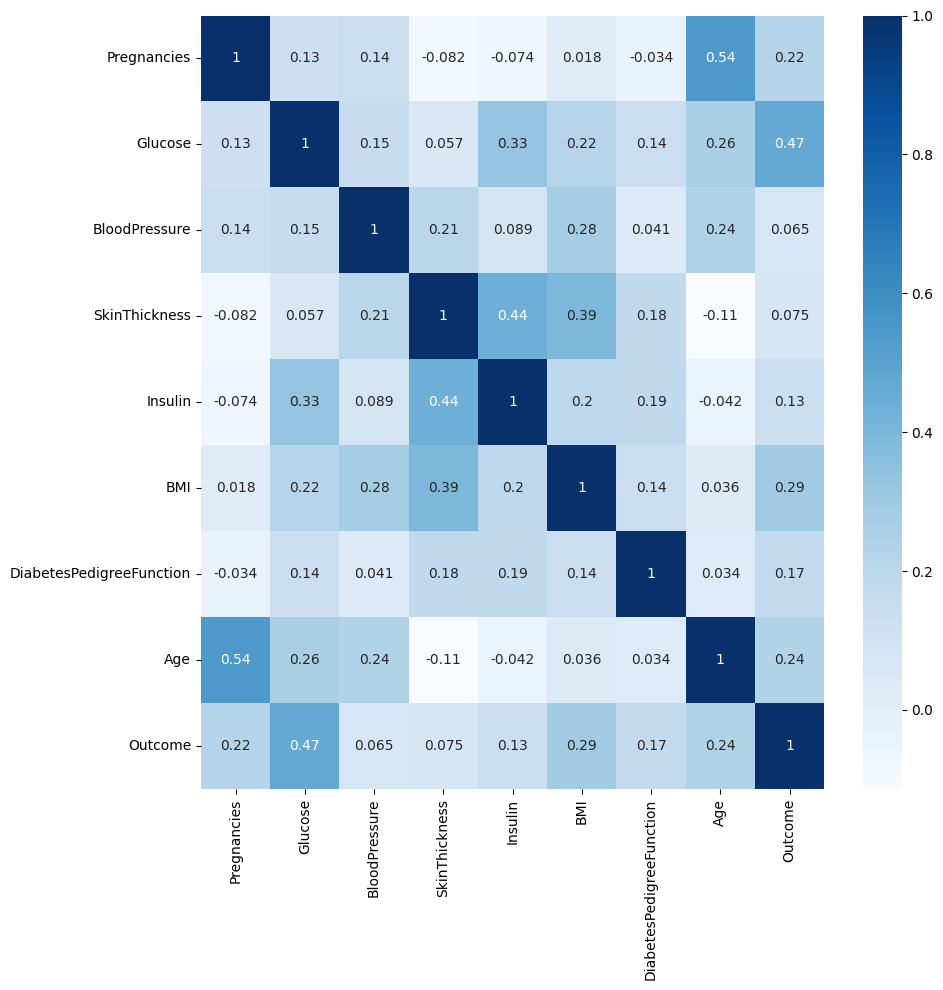

```python
plt.figure(figsize=(10,10))
sns.heatmap(df.corr(), cmap='Blues', annot=True)
plt.tight_layout()
```

# Kde Plot for visualization

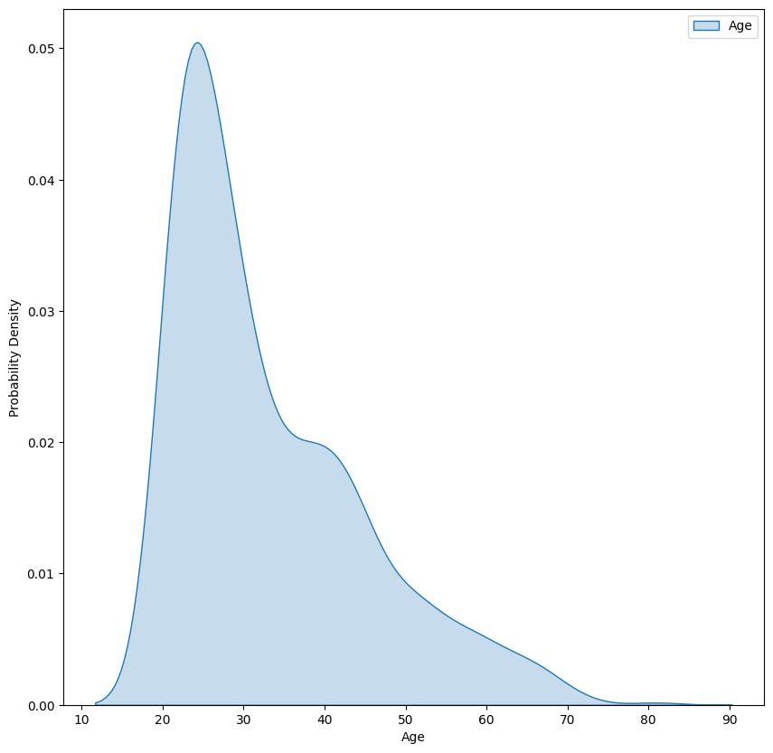

```python
plt.figure(figsize=(10, 10))
sns.kdeplot(df['Age'], fill=True, label="Age")  # Fixed parameter names
plt.xlabel('Age')
plt.ylabel('Probability Density')
plt.legend()
plt.show()
```

# Age Statistical Value

```python
df['Age'].describe(percentiles=[0.1,0.2,0.3,0.4,0.5,0.6,0.7,0.8,0.9,0.95,1])
```

```
count    768.000000
mean      33.240885
std       11.760232
min       21.000000
10%       22.000000
20%       23.000000
30%       25.000000
40%       27.000000
50%       29.000000
60%       33.000000
70%       38.000000
80%       42.600000
90%       51.000000
95%       58.000000
100%      81.000000
max       81.000000
Name: Age, dtype: float64
```

```python
df['Outcome'].value_counts()
```

```
Outcome
0    500
1    268
Name: count, dtype: int64
```

# Visualization of the Outcomes

```
The outcome values Outcome
0    500
1    268
Name: count, dtype: int64
```

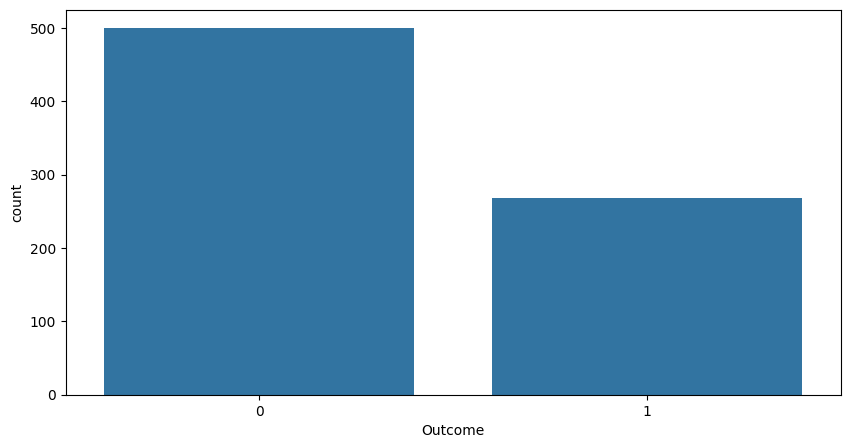

```python
print("The outcome values",df['Outcome'].value_counts())
plt.figure(figsize=(10,5))
sns.countplot(x='Outcome', data=df)
plt.show()
```

# Getting the arrya of the feature and Target columns

```python
X=df.drop(['Outcome'], axis=1).values
y=df['Outcome'].values
```

```python
from sklearn.model_selection import train_test_split
```

```python
X_train, X_test, y_train, y_test=train_test_split(X,y, test_size=0.45, random_state=45, stratify=y)
```

Some classification problems can exhibit a large imbalance in the distribution of the target classes: for instance there could be several times more negative samples than positive samples. In such cases it is recommended to use stratified sampling

# KNeighbours Classification

```python
from sklearn.neighbors import KNeighborsClassifier

neighbors=np.arange(1,9)
train_accuracy=np.empty(len(neighbors))
test_accuracy=np.empty(len(neighbors))

for i,k in enumerate(neighbors):
    knn=KNeighborsClassifier(n_neighbors=k)

    knn.fit(X_train, y_train)

    train_accuracy[i]=knn.score(X_train, y_train)

    test_accuracy[i]=knn.score(X_test, y_test)
```

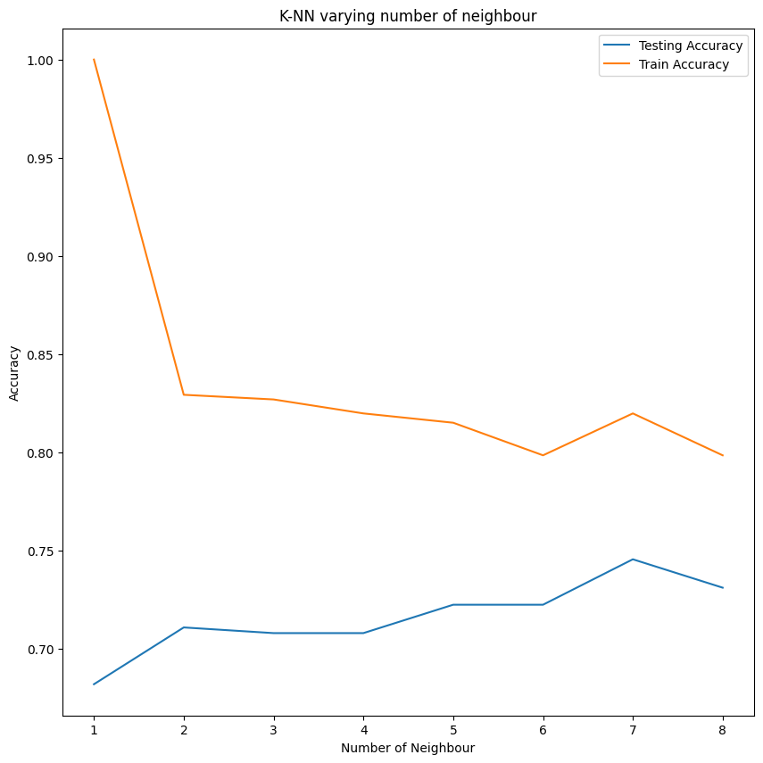

```python
plt.figure(figsize=(10,10))
plt.title("K-NN varying number of neighbour")
plt.plot(neighbors, test_accuracy, label="Testing Accuracy")
plt.plot(neighbors, train_accuracy, label="Train Accuracy")
plt.legend()
plt.xlabel("Number of Neighbour")
plt.ylabel("Accuracy")
plt.show()
```

# Inference

As test accracy is high at k=7, We adopt the KNeighborsClassifier with number of neighbours as 7

```python
knn=KNeighborsClassifier(n_neighbors=7)
knn.fit(X_train, y_train)
```

```
KNeighborsClassifier(n_neighbors=7)
```

```python
print(knn.score(X_test, y_test)*100)
```

```
74.56647398843931
```

# Confusion Matrix

```python
from sklearn.metrics import confusion_matrix
from sklearn import metrics
```

```python
y_pred=knn.predict(X_train)
```

# Evaluation of the model

```
Accuracy Score: 0.8199052132701422
Classification Report:
               precision    recall  f1-score   support

           0       0.84      0.89      0.87       275
           1       0.77      0.69      0.73       147

    accuracy                           0.82       422
   macro avg       0.81      0.79      0.80       422
weighted avg       0.82      0.82      0.82       422
```

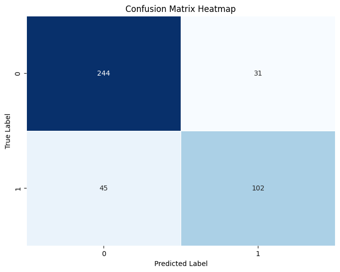

```python
# Accuracy Score
accuracy = metrics.accuracy_score(y_train, y_pred)
print("Accuracy Score:", accuracy)

# Classification Report
class_report = metrics.classification_report(y_train, y_pred)
print("Classification Report:\n", class_report)

# Confusion Matrix
# Compute confusion matrix
conf_matrix = metrics.confusion_matrix(y_train, y_pred)
plt.figure(figsize=(8, 6))
sns.heatmap(conf_matrix, annot=True, fmt="d", cmap="Blues", linewidths=0.5, cbar=False)
plt.xlabel("Predicted Label")
plt.ylabel("True Label")
plt.title("Confusion Matrix Heatmap")

plt.show()
```

# Evaluation of the test dataset

```python
# Predicting the Test data with model
y_test_pred=knn.predict(X_test)
```

# Evaluation Model

```
Accuracy Score: 0.7456647398843931
Classification Report:
               precision    recall  f1-score   support

           0       0.78      0.85      0.81       225
           1       0.66      0.55      0.60       121

    accuracy                           0.75       346
   macro avg       0.72      0.70      0.71       346
weighted avg       0.74      0.75      0.74       346
```

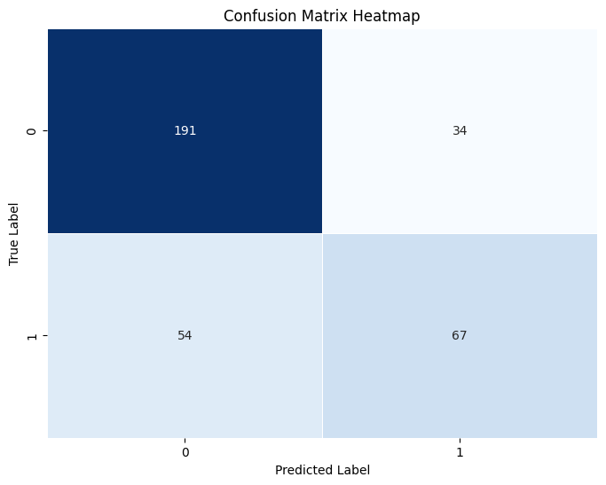

```python
# Accuracy Score
knn_acc = metrics.accuracy_score(y_test, y_test_pred)
print("Accuracy Score:", knn_acc)

# Classification Report
class_report = metrics.classification_report(y_test, y_test_pred)
print("Classification Report:\n", class_report)

# Confusion Matrix
conf_matrix = metrics.confusion_matrix(y_test, y_test_pred)
plt.figure(figsize=(8, 6))
sns.heatmap(conf_matrix, annot=True, fmt="d", cmap="Blues", linewidths=0.5, cbar=False)
plt.xlabel("Predicted Label")
plt.ylabel("True Label")
plt.title("Confusion Matrix Heatmap")

plt.show()
```

# Confusion Matrix

- Calculation

```python
cfm=confusion_matrix(y_test, y_test_pred)
trueNegative=cfm[0][0]
falsePossitive=cfm[0][1]
false_negative=cfm[1][0]
truePositive=cfm[1][1]
```

```python
print("Confusion Matrix", cfm)
```

```
Confusion Matrix [[191  34]
 [ 54  67]]
```

# Table of confusion Matrix

```python
pd.crosstab(y_test, y_test_pred, rownames=['True'], colnames=['Predicted'], margins=True)
```

| Predicted True | 0 | 1 | All |
| --- | --- | --- | --- |
| 0 | 191 | 34 | 225 |
| 1 | 54 | 67 | 121 |
| All | 245 | 101 | 346 |

```python
print("true negative", trueNegative)
print("False Positive", falsePossitive)
print("false Negative", false_negative)
print("True Positive", truePositive)
```

```
true negative 191
False Positive 34
false Negative 54
True Positive 67
```

# Accuracy

```python
print("correct prediction",
      round((trueNegative+truePositive)/len(y_test_pred)*100, 1),'%')
```

```
correct prediction 74.6 %
```

```python
from sklearn.metrics import classification_report
```

- There are four ways to check if the predictions are right or wrong:
- TN / True Negative: the case was negative and predicted negative
- TP / True Positive: the case was positive and predicted positive
- FN / False Negative: the case was positive but predicted negative
- FP / False Positive: the case was negative but predicted positive
- Precision — What percent of your predictions were correct?
- Precision is the ability of a classifier not to label an instance positive that is actually negative. For each class, it is defined as the ratio of true positives to the sum of a true positive and false positive.
- Precision:- Accuracy of positive predictions.
- Precision = TP/(TP + FP)
- Recall — What percent of the positive cases did you catch?
- Recall is the ability of a classifier to find all positive instances. For each class it is defined as the ratio of true positives to the sum of true positives and false negatives.
- Recall:- Fraction of positives that were correctly identified.
- Recall = TP/(TP+FN)
- F1 score — What percent of positive predictions were correct?
- The F1 score is a weighted harmonic mean of precision and recall such that the best score is 1.0 and the worst is 0.0. F1 scores are lower than accuracy measures as they embed precision and recall into their computation. As a rule of thumb, the weighted average of F1 should be used to compare classifier models, not global accuracy.
- F1 Score = 2*(Recall * Precision) / (Recall + Precision)
- Support
- Support is the number of actual occurrences of the class in the specified dataset. Imbalanced support in the training data may indicate structural weaknesses in the reported scores of the classifier and could indicate the need for stratified sampling or rebalancing. Support doesn’t change between models but instead diagnoses the evaluation process.

# ROC(Reciever Operating Curve)

```python
y_test_pred_prob=knn.predict_proba(X_test)[:,1]
```

```python
from sklearn.metrics import roc_curve
```

```python
fpr, tpr,thresholds=roc_curve(y_test,y_test_pred_prob)
```

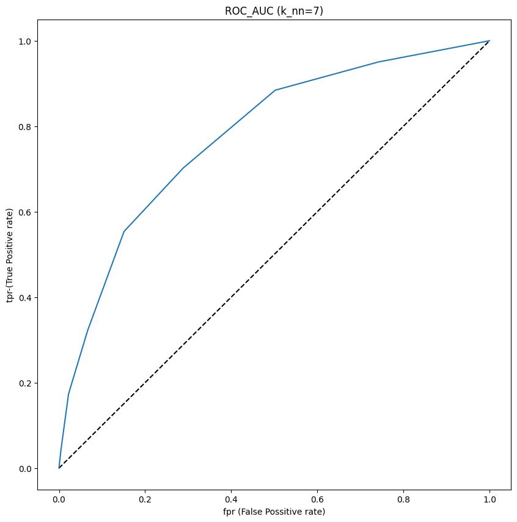

```python
plt.figure(figsize=(10,10))
plt.plot([0,1],[0,1],'k--')
plt.plot(fpr, tpr, label='knn')
plt.xlabel("fpr (False Possitive rate)")
plt.ylabel("tpr-(True Positive rate)")
plt.title("ROC_AUC (k_nn=7)")
plt.show()
```

# Inference

- The k-nn is very godd as we can see that it is not dumb model as AUC is more than 0.5 , Hence it is performing very good.

```python
from sklearn.metrics import roc_auc_score
print(roc_auc_score(y_test, y_test_pred_prob)*100)
```

```
77.73553719008265
```

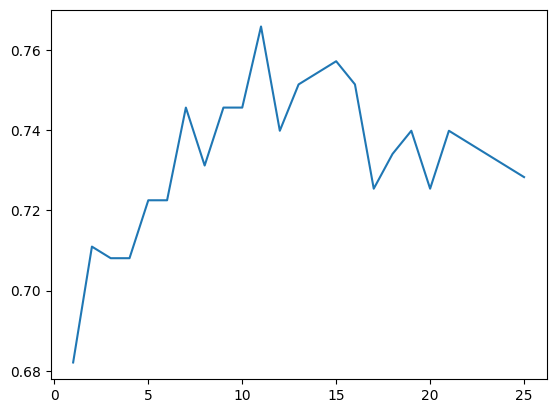

```python
k_range = list(range(1, 26))
scores = []
for i in k_range:
    knn = KNeighborsClassifier(n_neighbors=i)
    knn.fit(X_train, y_train)
    y_pred = knn.predict(X_test)
    scores.append(metrics.accuracy_score(y_test, y_pred))
plt.plot(k_range, scores)
plt.show()
```

# Cross Validation

Now before getting into the details of Hyperparamter tuning, let us understand the concept of Cross validation.

The trained model's performance is dependent on way the data is split. It might not representative of the model’s ability to generalize.

The solution is cross validation.

Cross-validation is a technique to evaluate predictive models by partitioning the original sample into a training set to train the model, and a test set to evaluate it.

# K-fold cross-validation

In k-fold cross-validation, the original sample is randomly partitioned into k equal size subsamples. Of the k subsamples, a single subsample is retained as the validation data for testing the model, and the remaining k-1 subsamples are used as training data. The cross-validation process is then repeated k times (the folds), with each of the k subsamples used exactly once as the validation data. The k results from the folds can then be averaged (or otherwise combined) to produce a single estimation. The advantage of this method is that all observations are used for both training and validation, and each observation is used for validation exactly once.

# Hyperparameter tuning

The value of k (i.e 7) we selected above was selected by observing the curve of accuracy vs number of neighbors. This is a primitive way of hyperparameter tuning.

There is a better way of doing it which involves:

1. Trying a bunch of different hyperparameter values
2. Fitting all of them separately
3. Checking how well each performs
4. Choosing the best performing one
5. Using cross-validation every time

Scikit-learn provides a simple way of achieving this using GridSearchCV i.e Grid Search cross-validation.

In almost any Machine Learning project, we train different models on the dataset and selecting the one with the best performance. However, there is almost a room for improvement as we cannot say for sure that this particular model is best for the problem at hand, hence our aim is to improve the model in any way possible. One important factor in the performances of these models are their hyperparameters, once we set appropriate values for these hyperparameters, the performance of a model can improve significantly. In this article, we will find out how we can find optimal values for the hyperparameters of a model by using GridSearchCV.

# GridSearchCV

# How does GridSearchCV work?

- GridSearchCV tries all the combinations of the values passed in the dictionary and evaluates the model for each combination using the Cross-Validation method.
- Hence after using this function we get accuracy/loss for every combination of hyperparameters and we can choose the one with the best performance.

# Use of GridSearch done below

```python
from sklearn.model_selection import  GridSearchCV
```

```python
param_grid={'n_neighbours':np.arange(1,50)}
```

```python
k_range = list(range(1, 31))
print(k_range)
```

```
[1, 2, 3, 4, 5, 6, 7, 8, 9, 10, 11, 12, 13, 14, 15, 16, 17, 18, 19, 20, 21, 22, 23, 24, 25, 26, 27, 28, 29, 30]
```

```python
param_grid = dict(n_neighbors=k_range)
print(param_grid)
```

```
{'n_neighbors': [1, 2, 3, 4, 5, 6, 7, 8, 9, 10, 11, 12, 13, 14, 15, 16, 17, 18, 19, 20, 21, 22, 23, 24, 25, 26, 27, 28, 29, 30]}
```

```python
grid = GridSearchCV(knn, param_grid, cv=10, scoring='accuracy', return_train_score=False)
grid.fit(X, y)
```

```
GridSearchCV(cv=10, estimator=KNeighborsClassifier(n_neighbors=25),
             param_grid={'n_neighbors': [1, 2, 3, 4, 5, 6, 7, 8, 9, 10, 11, 12,
                                         13, 14, 15, 16, 17, 18, 19, 20, 21, 22,
                                         23, 24, 25, 26, 27, 28, 29, 30]},
             scoring='accuracy')
```

1. estimator: Pass the model instance for which you want to check the hyperparameters.
2. params_grid: the dictionary object that holds the hyperparameters you want to try
3. scoring: evaluation metric that you want to use, you can simply pass a valid string/ object of evaluation metric
4. cv: number of cross-validation you have to try for each selected set of hyperparameters
5. verbose: you can set it to 1 to get the detailed print out while you fit the data to GridSearchCV
6. n_jobs: number of processes you wish to run in parallel for this task if it -1 it will use all available processors.

```python
grid_mean_scores = grid.cv_results_['mean_test_score']
print(grid_mean_scores)
```

```
[0.67966507 0.71223513 0.70305878 0.71871155 0.72137731 0.73571429
 0.73962748 0.73831169 0.73834586 0.74347232 0.73694463 0.74736842
 0.74220779 0.75391319 0.74480519 0.75261449 0.75529733 0.75528025
 0.74747095 0.74618934 0.75006835 0.75011962 0.74752221 0.74359193
 0.74620643 0.73316815 0.73708134 0.73053657 0.73185236 0.72535885]
```

```python
grid.best_score_
```

```
np.float64(0.7552973342447027)
```

```python
grid.best_params_
```

```
{'n_neighbors': 17}
```

# Conclusion

- As we can see that the accuracy score after the GridSerach is a bit high
- Gridseach worked in our case
- ROC-AUC is more than 0.5 , hence it is very good

# Save the Model

```python
import joblib

# Save the trained model
joblib.dump(knn, 'knn_diabetes_model.pkl')

print("Model saved successfully!")
```

```
Model saved successfully!
```

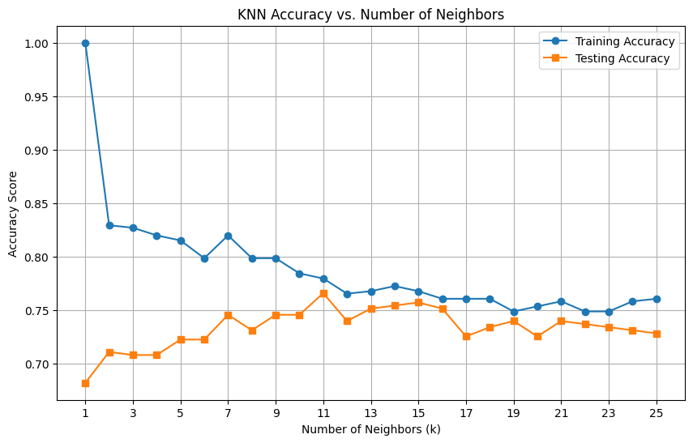

```python
import numpy as np
import matplotlib.pyplot as plt
from sklearn.neighbors import KNeighborsClassifier
from sklearn.metrics import accuracy_score

# Define range for k
k_range = range(1, 26)  # Testing k values from 1 to 25
train_scores = []
test_scores = []

# Loop through different values of k
for k in k_range:
    knn = KNeighborsClassifier(n_neighbors=k)
    knn.fit(X_train, y_train)

    # Predict for train and test data
    y_train_pred = knn.predict(X_train)
    y_test_pred = knn.predict(X_test)

    # Calculate accuracy
    train_scores.append(accuracy_score(y_train, y_train_pred))
    test_scores.append(accuracy_score(y_test, y_test_pred))

# Plot results
plt.figure(figsize=(10, 6))
plt.plot(k_range, train_scores, label="Training Accuracy", marker='o')
plt.plot(k_range, test_scores, label="Testing Accuracy", marker='s')

# Labels and title
plt.xlabel("Number of Neighbors (k)")
plt.ylabel("Accuracy Score")
plt.title("KNN Accuracy vs. Number of Neighbors")
plt.legend()
plt.xticks(np.arange(1, 26, step=2))
plt.grid(True)
plt.show()
```

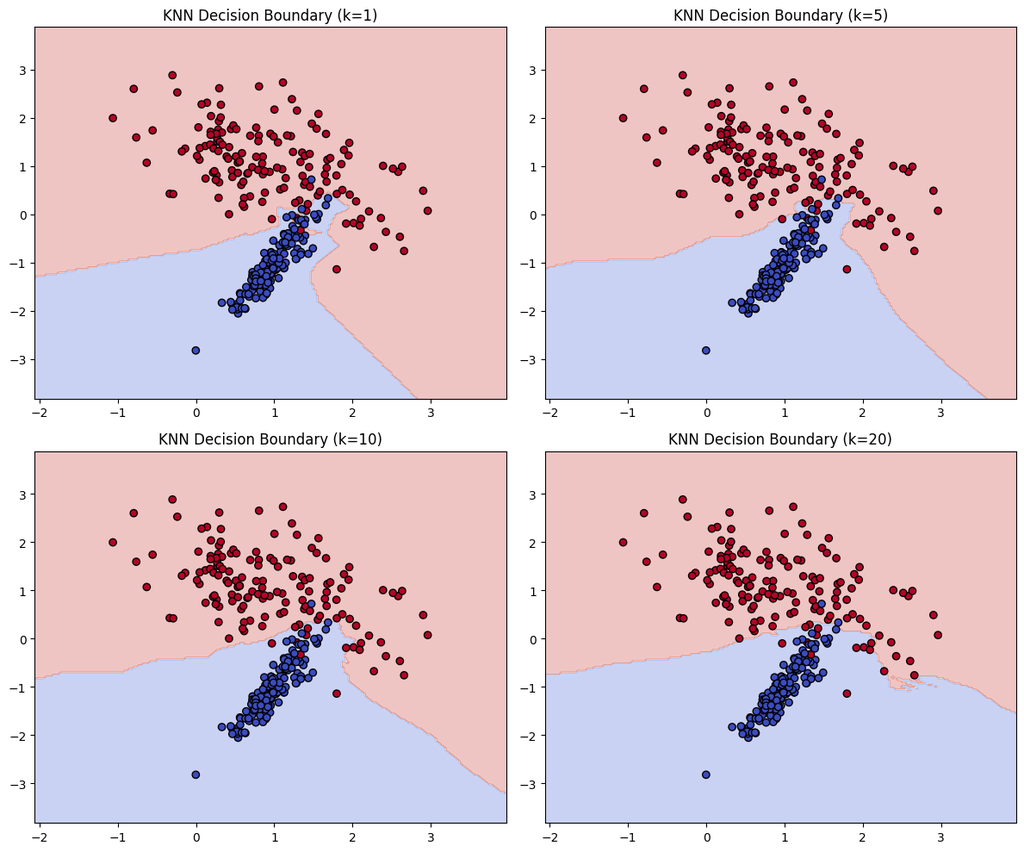

```python
import numpy as np
import matplotlib.pyplot as plt
from sklearn.neighbors import KNeighborsClassifier
from sklearn.datasets import make_classification
from sklearn.model_selection import train_test_split

# Create a simple classification dataset (2 features)
X, y = make_classification(n_samples=300, n_features=2,
                           n_informative=2, n_redundant=0,
                           n_clusters_per_class=1, random_state=42)

# Split dataset
X_train, X_test, y_train, y_test = train_test_split(X, y, test_size=0.3, random_state=42)

# Define different values of k
k_values = [1, 5, 10, 20]

plt.figure(figsize=(12, 10))

for i, k in enumerate(k_values):
    knn = KNeighborsClassifier(n_neighbors=k)
    knn.fit(X_train, y_train)

    # Create a mesh grid for decision boundary
    x_min, x_max = X[:, 0].min() - 1, X[:, 0].max() + 1
    y_min, y_max = X[:, 1].min() - 1, X[:, 1].max() + 1
    xx, yy = np.meshgrid(np.linspace(x_min, x_max, 200),
                         np.linspace(y_min, y_max, 200))

    Z = knn.predict(np.c_[xx.ravel(), yy.ravel()])
    Z = Z.reshape(xx.shape)

    # Plot decision boundary
    plt.subplot(2, 2, i + 1)
    plt.contourf(xx, yy, Z, alpha=0.3, cmap='coolwarm')
    plt.scatter(X[:, 0], X[:, 1], c=y, edgecolor='k', cmap='coolwarm')
    plt.title(f"KNN Decision Boundary (k={k})")

plt.tight_layout()
plt.show()
```